# Lab 5.1 - Nobel Laureates

Trey Tipton

Fall 2022

```r
library(tidyverse)
```

This analysis explores the data used by P. Aldhous in [this Buzzfeed article](https://www.buzzfeednews.com/article/peteraldhous/immigration-and-science). The article claims that one key factor in the US’s leadership in science and technology is immigration because while most living Nobel laureates in the sciences are based in the US, many of them were born in other countries.

## The Dataset

```r
nobel <- read_csv("data/nobel.csv")
```

This dataset contains information on nobel laureates. There are 935 observations in this dataset and 26 variables. Each observation represnts a Nobel laureate by giving their name, the year they won, birth and death dates, gender, country and city of birth and death, etc.

## Using the Intermediate Data Types

- `id`: ID number
- `firstname`: First name of laureate
- `surname`: Surname
- `year`: Year prize won
- `category`: Category of prize
- `affiliation`: Affiliation of laureate
- `city`: City of laureate in prize year
- `country`: Country of laureate in prize year
- `born_date`: Birth date of laureate
- `died_date`: Death date of laureate
- `gender`: Gender of laureate
- `born_city`: City where laureate was born
- `born_country`: Country where laureate was born
- `born_country_code`: Code of country where laureate was born
- `died_city`: City where laureate died
- `died_country`: Country where laureate died
- `died_country_code`: Code of country where laureate died
- `overall_motivation`: Overall motivation for recognition
- `share`: Number of other winners award is shared with
- `motivation`: Motivation for recognition

In a few cases the name of the city/country changed after laureate was given (e.g. in 1975 Bosnia and Herzegovina was part of the Socialist Federative Republic of Yugoslavia). In these cases the variables below reflect a different name than their counterparts without the suffix `_original`.

- `born_country_original`: Original country where laureate was born
- `born_city_original`: Original city where laureate was born
- `died_country_original`: Original country where laureate died
- `died_city_original`: Original city where laureate died
- `city_original`: Original city where laureate lived at the time of winning the award
- `country_original`: Original country where laureate lived at the time of winning the award

## Cleansing the Data

```r
nobel_living <- nobel %>%
  filter(!is.na(country) & !gender == 'org' & is.na(died_date))
```

After including only: - laureates for whom country is available (i.e., it isn’t `NA` – remember to use the `is.na()` function) - laureates who are people as opposed to organizations (organizations are denoted with `"org"` as their gender) - laureates who are still alive (their died_date is `NA`)

We are left with a data frame with 228 observations.

## Determining Where Nobel Laureates Lived

The Buzzfeed article claims that most living Nobel laureates were based in the US when they won their prizes. First, we’ll create a new variable to identify whether the laureate was in the US when they won their prize.

We include a `mutate()` function that uses a functional variant of the classic “if” statement, called `if_else()`, to create this variable. The arguments to this new function, to be covered in more detail later in the course, are:

- the condition for which we’re testing (e.g., is the country the USA?)
- the value to use if the condition is true (e.g., if `country` is equal to `"USA"`, it gives us `"USA"`)
- the value to use otherwise (e.g., if the country isn’t `"USA"`, we get `"Other"`).

```r
values <- c('Physics', 'Medicine', 'Chemistry', 'Economics')

nobel_living_science <- nobel_living %>%
  mutate(country_us = if_else(country == "USA", "USA", "Other")) %>%
  mutate(born_country_us = if_else(born_country == "USA", "USA", "Other")) %>%
  filter(category %in% values)
```

Create a faceted bar plot, with horizontal bars, visualizing the relationship between the category of prize and whether the laureate was in the US when they won the Nobel prize. Interpret your visualization, and say a few words about whether the Buzzfeed headline is supported by the data.

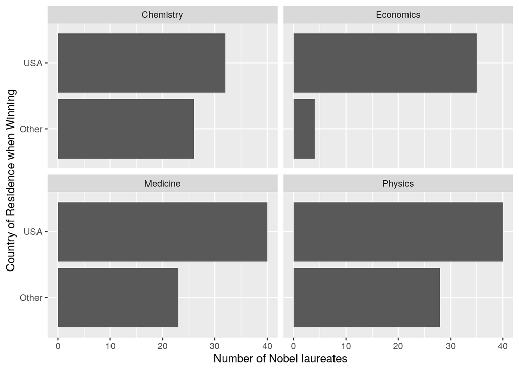

```r
nobel_living_science %>%
  ggplot(aes(y = country_us)) +
  geom_bar() +
  facet_wrap(~category) +
  labs(x = "Number of Nobel laureates", y = "Country of Residence when Winning")
```

According to this bar plot, there are more Nobel laureates that resided in the USA during the time of winning than any other country. The buzz feed claim is correct that most living Nobel laureates in the sciences are based in the US.

## Determining Where Nobel Laureates Were Born

Remake your visualization and add a second variable: whether the laureate was born in the US or not. Your final visualization should contain a facet for each category, within each facet a bar for whether they won the award in the US or not, and within each bar whether they were born in the US or not. (Don’t over-think this: you can do this by just adding another aesthetic mapping!) Based on your visualization, do the data appear to support Buzzfeed’s claim? Explain your reasoning in 1-2 sentences.

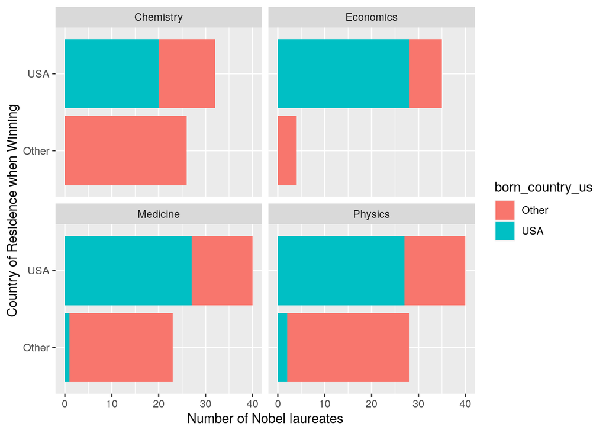

```r
nobel_living_science %>%
  ggplot(aes(y = country_us, fill = born_country_us)) +
  geom_bar() +
  facet_wrap(~category) +
  labs(x = "Number of Nobel laureates", y = "Country of Residence when Winning")
```

The data appear to support Buzzfeed’s claim because although most of the Nobel laureates that won in the USA were also born in the USA, there is still many of them who were born in other countries.

## Determining Where Immigrant Nobel Laureates Were Born

```r
filter(nobel_living_science, country == 'USA' & !born_country == 'USA') %>%
  count(born_country, sort = TRUE)
```

```
## # A tibble: 21 × 2
##    born_country       n
##    <chr>          <int>
##  1 Germany            7
##  2 United Kingdom     7
##  3 China              5
##  4 Canada             4
##  5 Japan              3
##  6 Australia          2
##  7 Israel             2
##  8 Norway             2
##  9 Austria            1
## 10 Finland            1
## # … with 11 more rows
```